# Intro to GitHub

Spencer Lyon

2016-02-05

# Git `remote`s

# What's a `remote`?

- A git repo can be on your hard drive: called local
- A `remote` is a copy of the repository on someone else's hard drive or server
- You `git push` commits from local to remote
- `git pull` commits from remote to local

# Collaboration

- Working with remotes enables many [workflows](https://git-scm.com/book/en/v2/Distributed-Git-Distributed-Workflows)
- One common workflow (image taken from [here](https://git-scm.com/book/en/v2/Distributed-Git-Distributed-Workflows))

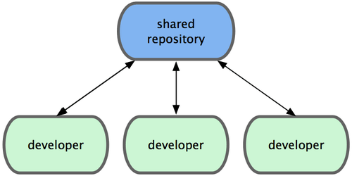

Centralized workflow

# [GitHub](https://github.com)

# Facts

- GitHub is a common place to have a `remote`
  - [Over 2.2 million](http://githut.info) active repositories
  - Unlimited free public repositories
  - 5 free private repositories for academics

# GitHub Collaboration

- Permission management: only certain users can `push`
- Forking: anyone can create a copy of any (visible) repository under their account
- Pull requests: system for project maintainers to review proposed changes before accepting them
- Automated testing (CI) and coverage

# Example

# quantecon_nyu_2016

- Add this lecture to course repo
- Steps:
  1. Login to github (online)
  2. Clone repository

     ```bash
     git clone https://github.com/jstac/quantecon_nyu_2016.git
     ```

  3. Fork repository (online)
  4. Add `remote` that points to fork

     ```bash
     git remote add fork https://github.com/spencerlyon2/quantecon_nyu_2016.git
     ```

# Steps (continued)

- More steps
  5. `add` + `commit` files

     ```
     git add files
     git commit -m "Adding github intro slides"
     ```

  6. `push` to fork

     ```
     git push fork master
     ```

  7. Open pull request (online)

# Exercise

# Pushing homework

- We will let you practice hw submission process
- Steps
  - Create account on github
  - Clone [homework repository](https://github.com/jstac/quantecon_nyu_2016_homework)
  - Fork homework repo
  - Add your fork as remote
  - Create file `firstname_lastname` in folder `hw_github_intro`
  - Leave short message in file
  - Add and commit the file
  - Push to fork
  - Submit pull request

# Extras

# SSH keys

- Two modes of authenticating to github: https, SSH
- https will require you to enter password on every push
- Adding ssh-key removes this requirement
- Follow these steps:
  - `ssh-keygen`: follow prompts
  - Copy the output of `cat ~/.ssh/id_rsa.pub` (use shift-c)
    - NOTE: path `~/.ssh/id_rsa.pub` might be different depending on your answers to previous step
    - Important part is to get the `.pub` version
  - Go to github account [settings](https://github.com/settings/profile)
  - Click "ssh keys" link on left, then "New ssh key"
  - Give it a title (name) and paste clipboard contents in key
  - Click big green "add SSH key button"